# Project 6: Ahmed S Alkhalifah

# Bank Churn Prediction

```python
import pandas as pd
import numpy as np
import matplotlib.pyplot as plt
import seaborn as sns
```

```python
customers = pd.read_csv("bank.csv", index_col='RowNumber')
```

```python
customers.head()
```

| RowNumber | CustomerId | Surname | CreditScore | Geography | Gender | Age | Tenure | Balance | NumOfProducts | HasCrCard | IsActiveMember | EstimatedSalary | Exited |
| --- | --- | --- | --- | --- | --- | --- | --- | --- | --- | --- | --- | --- | --- |
| 1 | 15634602 | Hargrave | 619 | France | Female | 42 | 2 | 0.00 | 1 | 1 | 1 | 101348.88 | 1 |
| 2 | 15647311 | Hill | 608 | Spain | Female | 41 | 1 | 83807.86 | 1 | 0 | 1 | 112542.58 | 0 |
| 3 | 15619304 | Onio | 502 | France | Female | 42 | 8 | 159660.80 | 3 | 1 | 0 | 113931.57 | 1 |
| 4 | 15701354 | Boni | 699 | France | Female | 39 | 1 | 0.00 | 2 | 0 | 0 | 93826.63 | 0 |
| 5 | 15737888 | Mitchell | 850 | Spain | Female | 43 | 2 | 125510.82 | 1 | 1 | 1 | 79084.10 | 0 |

```python
customers.info()
```

```
<class 'pandas.core.frame.DataFrame'>
Int64Index: 10000 entries, 1 to 10000
Data columns (total 13 columns):
CustomerId         10000 non-null int64
Surname            10000 non-null object
CreditScore        10000 non-null int64
Geography          10000 non-null object
Gender             10000 non-null object
Age                10000 non-null int64
Tenure             10000 non-null int64
Balance            10000 non-null float64
NumOfProducts      10000 non-null int64
HasCrCard          10000 non-null int64
IsActiveMember     10000 non-null int64
EstimatedSalary    10000 non-null float64
Exited             10000 non-null int64
dtypes: float64(2), int64(8), object(3)
memory usage: 1.1+ MB
```

```python
customers.isnull().sum()
```

```
CustomerId         0
Surname            0
CreditScore        0
Geography          0
Gender             0
Age                0
Tenure             0
Balance            0
NumOfProducts      0
HasCrCard          0
IsActiveMember     0
EstimatedSalary    0
Exited             0
dtype: int64
```

```python
customers.duplicated().sum()
```

```
0
```

```python
customers.duplicated(subset=['CustomerId']).sum()
```

```
0
```

# Data summery:

containes 14 distinct features:

1 Row number: Unique number, to be dropped from the data

2 CustomerId: Unique number, to be dropped from the data

3 Surname: Unique variable, to be dropped from the data

4 CreditScore: Numeric variable

5 Geography: Categorical variable

6 Gender: Categorical variable

7 Age: Numeric variable

8 Tenure: Categorical variable

9 Balance: Numeric variable

0 NumOfProducts: Categorical variable

10 HasCrCard: Categorical variable

11 IsActiveMember: Categorical variable

12 EstimatedSalary: Numeric variable

13 Exited: Target variable to be included in the model

There is no Null values, No duplicated to be removed

```python
# Drop RowNumber and CustomerId because it won't be useful in predictive task
customers.drop(['CustomerId', 'Surname'], axis=1, inplace=True)
```

```python
# Convert object dtype into category
cat_features = ['Geography', 'Gender', 'HasCrCard', 'IsActiveMember', 'NumOfProducts', 'Tenure','Exited']
for colname in cat_features:
    customers[colname] = customers[colname].astype('category')
```

```python
for colname in cat_features:
    print(customers[colname].unique())
```

```
[France, Spain, Germany]
Categories (3, object): [France, Spain, Germany]
[Female, Male]
Categories (2, object): [Female, Male]
[1, 0]
Categories (2, int64): [1, 0]
[1, 0]
Categories (2, int64): [1, 0]
[1, 3, 2, 4]
Categories (4, int64): [1, 3, 2, 4]
[2, 1, 8, 7, 4, ..., 3, 10, 5, 9, 0]
Length: 11
Categories (11, int64): [2, 1, 8, 7, ..., 10, 5, 9, 0]
[1, 0]
Categories (2, int64): [1, 0]
```

# Uni and Bi variate analysis

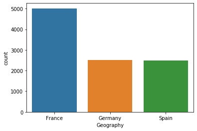

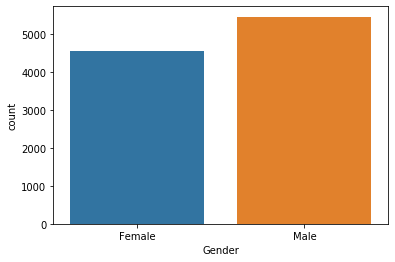

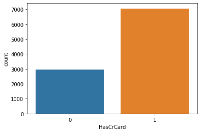

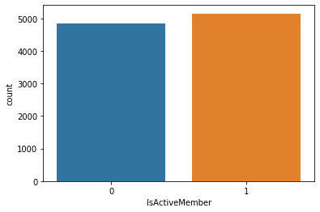

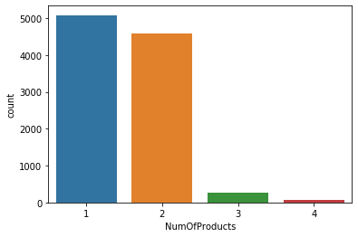

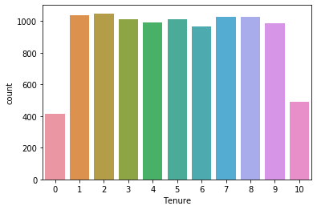

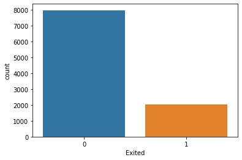

```python
for i in cat_features:
    sns.countplot(x=i, data=customers)
    plt.show()
```

```python
# Describing cont. variables for mean, Std and quartiles
customers.describe()
```

|  | CreditScore | Age | Balance | EstimatedSalary |
| --- | --- | --- | --- | --- |
| count | 10000.000000 | 10000.000000 | 10000.000000 | 10000.000000 |
| mean | 650.528800 | 38.921800 | 76485.889288 | 100090.239881 |
| std | 96.653299 | 10.487806 | 62397.405202 | 57510.492818 |
| min | 350.000000 | 18.000000 | 0.000000 | 11.580000 |
| 25% | 584.000000 | 32.000000 | 0.000000 | 51002.110000 |
| 50% | 652.000000 | 37.000000 | 97198.540000 | 100193.915000 |
| 75% | 718.000000 | 44.000000 | 127644.240000 | 149388.247500 |
| max | 850.000000 | 92.000000 | 250898.090000 | 199992.480000 |

```python
customers.skew()
```

[output not shown]

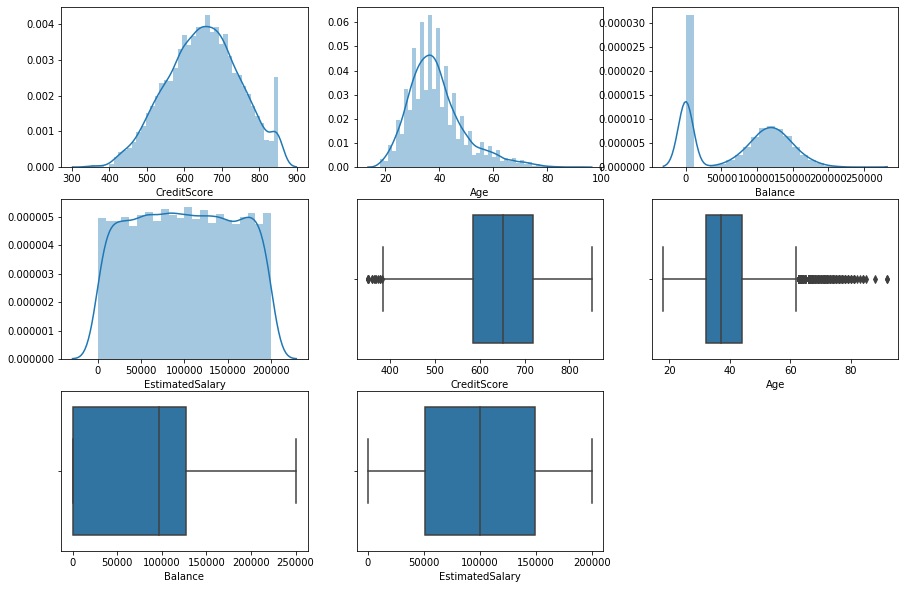

```python
cont_features=['CreditScore','Age','Balance','EstimatedSalary']
fig, ax = plt.subplots(figsize = (15,10))
pos = 1
for i in cont_features:
    plt.subplot(3, 3, pos)
    sns.distplot(customers[i])
    pos += 1


for i in cont_features:
    plt.subplot(3, 3, pos)
    sns.boxplot(customers[i])
    pos += 1
```

# Univariate analysis

most of the customers are from France, males, have 1 credit card and 1 to 2 products.

Most of the customers didnt exit... which might make some majority bias in the model formulation

Outliers can be identified in the creditScore and age variables